# MolBreeding GBTS — simulation-calibrated ancestry calling

Author

Fausto Rodríguez-Zapata

Published

June 17, 2026

**Repo:** sawers-rellan-labs/zealtiger

> Simulation-calibrated ancestry calling for **MolBreeding GBTS** (Source 5, ~110× target-capture, wideseq-filtered). Outputs are **isolated** to `results/sim_calibration/`; the frozen direct comparison (`docs/molbreeding_vs_skim.html`) is untouched. The skim companion is `skim_sim_calibration.qmd`; the cross-platform comparison is `molbreeding_vs_skim_calibrated.qmd`. Methodology: `docs/15-rigidity-and-scoring.md`, `docs/13-single-locus-validation.md`, `docs/14-interference-and-rigidity.md`.

## What this does

A three-layer, simulation-calibrated benchmark of the GBTS ancestry caller: (layer 2) **calibrate / validate the coverage model** against the real GBTS (capped to 20× for the betabinomial fit cost); (layer 3) call RTIGER on the degraded truth at the **derived rigidity r=2** (the FP+FN argmin from the truth sweep; `docs/15`), scored against the known truth; then the **three-`f_i` bias decomposition** (`docs/13` §5c-d): p₀ (neutral breeding) vs degraded-sim (method bias) vs real calls (bias + biology). The simulation baseline separates **method bias** from **real biology**.

## Setup

```r
library(tidyverse); library(data.table)
purrr::walk(fs::dir_ls("R", glob = "*.R"), source)
set.seed(params$seed)
fs::dir_create(file.path(params$out_dir, "figures"))

p0 <- single_locus_p0(n_bc = 2L, n_self = 3L)   # breeding-scheme expectation

# per-sample REF/Het/ALT Mb fractions from a state-segment table
seg_fractions <- function(seg) {
  seg %>% mutate(mb = (end_bp - start_bp) / 1e6) %>%
    group_by(name) %>%
    summarise(REF = sum(mb[state == 0]), Het = sum(mb[state == 1]),
              ALT = sum(mb[state == 2]), .groups = "drop") %>%
    mutate(tot = REF + Het + ALT) %>% filter(tot > 0) %>%
    transmute(name, REF = REF/tot, Het = Het/tot, ALT = ALT/tot)
}
cat(sprintf("p0  REF %.3f  Het %.3f  ALT %.3f\n", p0["REF"], p0["Het"], p0["ALT"]))
```

```
p0  REF 0.859  Het 0.031  ALT 0.109
```

# GBTS (Source 5, ~110× target-capture, wideseq-filtered)

The wideseq-filtered (`SNP_wsfilt`) **high-confidence** set: 9,157 sites validated in prior genotyping and selected for clean Poisson coverage in the skim. ~100% covered at **~110×** (capped to **20×** for the betabinomial fit cost), so het is **resolved** — the opposite regime to the skim. Informative density ~4.3/Mb (sparser than skim’s 6.7; GBTS’s edge is *coverage*, not marker count). Derived rigidity **r=2** (FP+FN sweep vs truth; `docs/15`; *not* the borrowed r=8).

## Layer 2 — Observation model

```r
g <- data.table::fread(params$gbts_gatk)
real <- g[, .(depth = mean(TOTAL_COUNT), missing = mean(TOTAL_COUNT == 0),
              het = mean(REF_COUNT > 0 & ALT_COUNT > 0)), by = SAMPLE]
ss <- read_csv(file.path(params$gbts_bench, "sample_stats.csv"), show_col_types = FALSE)
tibble(source = c("real GBTS (raw)", "real GBTS (capped 20×, fit input)", "degraded sim (20×)"),
       mean_depth  = c(mean(real$depth), 20, mean(ss$mean_depth)),
       missingness = c(mean(real$missing), mean(real$missing), mean(ss$missing_obs)),
       obs_het_rate = c(mean(real$het), NA, NA)) %>%
  knitr::kable(digits = 4)
```

| source | mean_depth | missingness | obs_het_rate |
| --- | --- | --- | --- |
| real GBTS (raw) | 110.1883 | 0.0012 | 0.086 |
| real GBTS (capped 20×, fit input) | 20.0000 | 0.0012 | NA |
| degraded sim (20×) | 20.0042 | 0.0012 | NA |

**Read:** real GBTS is ~110×, ~0.1 % missing — near-complete. The betabinomial fit cost caps it to **20×** (the fit input), which the sim benchmark matches (20×, ~0.1 % missing). At 20× het is fully resolved (vs the skim’s ~1.5 reads), so there is **no het-undercall** here. Observation model validated at the capped level.

## Layer 3 — Recovery (degraded sim, r = 2)

```r
sc <- file.path(params$gbts_bench, "scoring")
read_csv(file.path(sc, "segment_scores.csv"), show_col_types = FALSE) %>%
  select(class, n_truth, n_called, precision, recall, F1) %>%
  knitr::kable(digits = 3, caption = "GBTS segment recovery at r=2 (reciprocal overlap ≥ 0.5)")
```

GBTS segment recovery at r=2 (reciprocal overlap ≥ 0.5)

| class | n_truth | n_called | precision | recall | F1 |
| --- | --- | --- | --- | --- | --- |
| homozygous_donor | 851 | 834 | 1.000 | 0.980 | 0.990 |
| heterozygous | 452 | 432 | 0.986 | 0.942 | 0.964 |
| donor_present | 1303 | 1266 | 0.999 | 0.971 | 0.985 |

```r
read_csv(file.path(sc, "crossover_scores.csv"), show_col_types = FALSE) %>%
  knitr::kable(digits = 3, caption = "GBTS crossover recovery")
```

GBTS crossover recovery

| call_set | mean_true_co | mean_called_co | co_bias | co_rmse |
| --- | --- | --- | --- | --- |
| RTIGER | 20.38 | 19.9 | -0.48 | 1.01 |

**Read:** recovery is excellent — donor F1 ≈ 0.99, **het F1 ≈ 0.96**, CO bias ≈ −0.5 (vs skim’s 0.95 / 0.89 / −1.7). High coverage resolves the het and crossovers the skim misses, so the **method bias is minimal**.

## Three-`f_i` decomposition

1. p₀ (neutral breeding) — (2) degraded-sim calls (method bias) — (3) real GBTS calls (bias + biology). The correct reference for the real data is **(2)**, not p₀.

```r
sim_g  <- seg_fractions(read_rtiger_segments(file.path(params$gbts_bench, "rtiger_out_r2", "rtiger_result.rds")))
real_g <- seg_fractions(read_csv(params$gbts_calls, show_col_types = FALSE) %>%
                          transmute(name, chr, start_bp, end_bp, state))
fig <- tibble(
  f_i = factor(c("(1) p0 breeding", "(2) degraded-sim", "(3) real GBTS"),
               levels = c("(1) p0 breeding", "(2) degraded-sim", "(3) real GBTS")),
  REF = c(p0["REF"], mean(sim_g$REF), mean(real_g$REF)),
  Het = c(p0["Het"], mean(sim_g$Het), mean(real_g$Het)),
  ALT = c(p0["ALT"], mean(sim_g$ALT), mean(real_g$ALT)),
  n   = c(NA, nrow(sim_g), nrow(real_g)))
knitr::kable(fig, digits = 4)
```

| f_i | REF | Het | ALT | n |
| --- | --- | --- | --- | --- |
| (1) p0 breeding | 0.8594 | 0.0312 | 0.1094 | NA |
| (2) degraded-sim | 0.8570 | 0.0307 | 0.1123 | 100 |
| (3) real GBTS | 0.8748 | 0.1030 | 0.0221 | 16 |

```r
cat(sprintf("(2)-(1) method bias:  Het %+.4f  ALT %+.4f\n",
            fig$Het[2]-fig$Het[1], fig$ALT[2]-fig$ALT[1]))
```

```
(2)-(1) method bias:  Het -0.0005  ALT +0.0029
```

```r
cat(sprintf("(3)-(2) real biology: Het %+.4f  ALT %+.4f  [N=%d]\n",
            fig$Het[3]-fig$Het[2], fig$ALT[3]-fig$ALT[2], fig$n[3]))
```

```
(3)-(2) real biology: Het +0.0723  ALT -0.0901  [N=16]
```

```r
write_csv(fig, file.path(params$out_dir, "gbts_three_fi_r2.csv"))
```

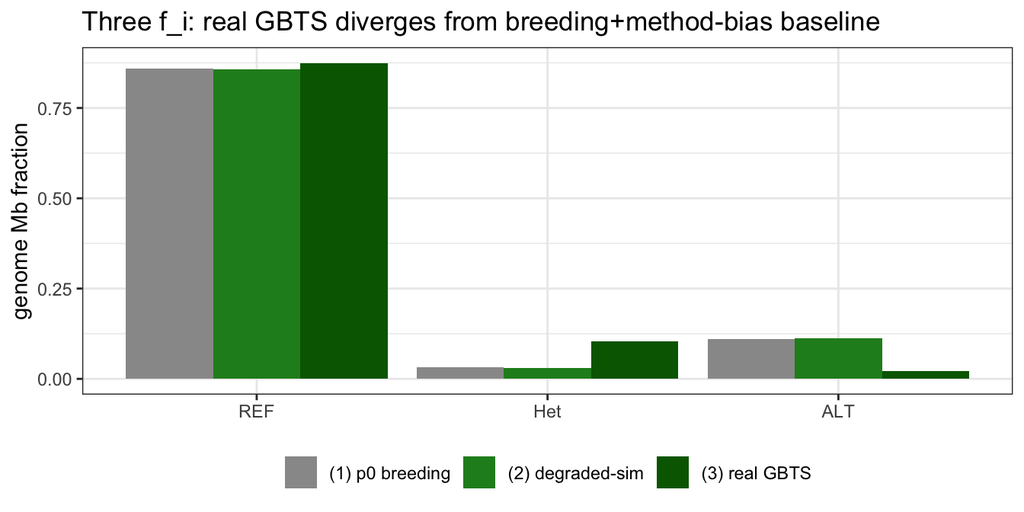

```r
fig %>% select(-n) %>% pivot_longer(c(REF, Het, ALT), names_to = "state") %>%
  mutate(state = factor(state, c("REF", "Het", "ALT"))) %>%
  ggplot(aes(state, value, fill = f_i)) +
  geom_col(position = "dodge") +
  scale_fill_manual(values = c("(1) p0 breeding"="grey60", "(2) degraded-sim"="forestgreen",
                               "(3) real GBTS"="darkgreen")) +
  labs(x = NULL, y = "genome Mb fraction", fill = NULL,
       title = "Three f_i: real GBTS diverges from breeding+method-bias baseline") +
  theme_bw() + theme(legend.position = "bottom")
```

**Read.** Method bias ≈0. Real biology: **Het +0.072, ALT −0.090** — a heterozygote excess / donor-homozygote deficit even *larger* than the skim’s, because GBTS resolves het the skim under-calls. N=16, but the signal is 3–14 SE; donor dosage **0.074** vs 0.125. The skim platform reaches the **same** conclusion independently (`skim_sim_calibration.qmd`); the cross-platform comparison is `molbreeding_vs_skim_calibrated.qmd`.

## Notes

- GBTS is **16 samples** (14 teosinte NILs + 2 B73-bulk checks) → three-`f_i` / dosage means are reliable but CIs are wide; Hotelling is underpowered. Report mean ± SE.
- GBTS is fit at the **capped 20×** (betabinomial cost); real raw is 110×. The layer-2 depth comparison is at the capped level.
- Outputs isolated under `params$out_dir`; the old `data/molbreeding_gbts/` is untouched.